# How Effective is Principal Component Analysis?

Zach Schuster

October 24, 2018

I’d like to understand how effective preprocessing a data set using PCA is for binary classification. To do this, I will use a data set with information on pulsar stars and a binary label. The data can be found [here on Kaggle](https://www.kaggle.com/pavanraj159/predicting-a-pulsar-star).

In addition, I will use the data.table package for any necessary data manipulation.

## Exploration

```r
require(data.table, quietly = TRUE)
stars = fread("pulsar_stars.csv", header = TRUE)

# take a look at the data
knitr::kable(head(stars), digits = 2)
```

| Mean of the integrated profile | Standard deviation of the integrated profile | Excess kurtosis of the integrated profile | Skewness of the integrated profile | Mean of the DM-SNR curve | Standard deviation of the DM-SNR curve | Excess kurtosis of the DM-SNR curve | Skewness of the DM-SNR curve | target_class |
| --- | --- | --- | --- | --- | --- | --- | --- | --- |
| 140.56 | 55.68 | -0.23 | -0.70 | 3.20 | 19.11 | 7.98 | 74.24 | 0 |
| 102.51 | 58.88 | 0.47 | -0.52 | 1.68 | 14.86 | 10.58 | 127.39 | 0 |
| 103.02 | 39.34 | 0.32 | 1.05 | 3.12 | 21.74 | 7.74 | 63.17 | 0 |
| 136.75 | 57.18 | -0.07 | -0.64 | 3.64 | 20.96 | 6.90 | 53.59 | 0 |
| 88.73 | 40.67 | 0.60 | 1.12 | 1.18 | 11.47 | 14.27 | 252.57 | 0 |
| 93.57 | 46.70 | 0.53 | 0.42 | 1.64 | 14.55 | 10.62 | 131.39 | 0 |

For more efficient use of space, I will rename the columns

```r
new_names = c("mean_IP","sd_IP","ek_IP","skew_IP",
              "mean_DM-SNR", "sd_DM-SNR", "ek_DM-SNR", "skew_DM-SNR",
              "target")
setnames(stars, names(stars), new_names)
```

It looks like we have 8 numeric columns of predictor variables. When looking further, there are two sets of 4 columns that take measurements on the “integrated profile” and the “DM-SNR”. It is possible that variables are correlated with eachother.

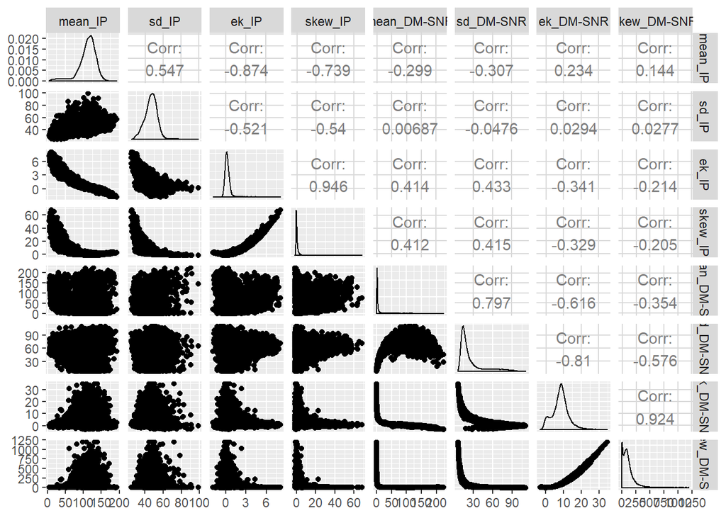

```r
GGally::ggpairs(stars[, !"target"])
```

As we expected, measures related to either the integrated profile or DM-SNR are highly correlated while their is not much correlation between measures on integrated profile and measures on SM-SNR.

This may be a good scenario for PCA!

### Class Distribution

Something we should note, and an added complication is the imbalanced class distribution.

```r
table(stars$target)
```

```
##
##     0     1
## 16259  1639
```

```r
round(table(stars$target)/length(stars$target), 3)*100
```

```
##
##    0    1
## 90.8  9.2
```

Here we see that only 9.2% of observations are actually pulsar stars! This provides an opportunity test out some sort of sampling.

## PCA

For the sake of learning, let’s manually run PCA (except for the eigen decomposition!) and project into 8 dimensions (the same as the original data set).

```r
# split data into target and covariates
target = stars[["target"]]
X = stars[, !"target"]

# compute covariance matrix
cov_X = cov(X)

# compute eigen vals and eigen vectors
eigens = eigen(cov_X)

PCA = as.data.table(cbind(scale(X, scale = FALSE) %*% eigens$vectors, target))
setnames(PCA, names(PCA), c(paste("pc", 1:8, sep = "_"), "target"))

# take a look at the head of our new data set
knitr::kable(head(PCA), digits = 2,
             caption = "Principle Components")
```

Principle Components

| pc_1 | pc_2 | pc_3 | pc_4 | pc_5 | pc_6 | pc_7 | pc_8 | target |
| --- | --- | --- | --- | --- | --- | --- | --- | --- |
| 27.19 | 29.68 | 19.48 | -3.04 | 3.12 | -4.33 | -0.04 | 0.01 | 0 |
| -24.48 | 6.02 | -11.39 | -5.34 | 14.00 | -2.18 | 0.66 | -0.01 | 0 |
| 39.94 | 10.83 | -14.77 | -2.10 | -4.44 | 3.47 | 0.10 | 0.13 | 0 |
| 48.00 | 29.83 | 16.33 | -2.84 | 5.30 | -4.49 | -0.35 | -0.06 | 0 |
| -147.92 | -18.56 | -22.30 | -1.58 | -0.32 | 3.92 | 0.25 | 0.08 | 0 |
| -28.07 | 0.47 | -20.92 | -5.23 | 4.39 | 2.10 | 0.47 | 0.06 | 0 |

## Cumulative Variance Explained by Component

We can build a nice plot to visualize how much variation is explained by each component.

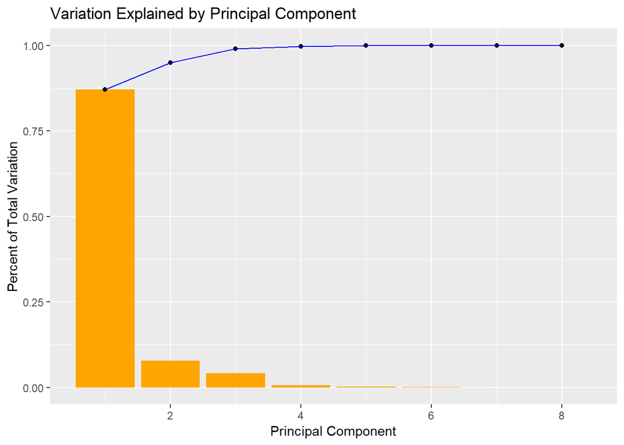

```r
require(ggplot2, quietly = TRUE)

norm_eig_values = eigens$values/sum(eigens$values)
cum_sum = cumsum(norm_eig_values)


ggplot(mapping = aes(x = 1:length(norm_eig_values), y = norm_eig_values)) +
    geom_bar(stat = "identity", fill = "orange") +
    geom_point(aes(y = cum_sum)) +
    geom_line(aes(y = cum_sum), col = "blue") +
    labs(title = "Variation Explained by Principal Component",
         x = "Principal Component",
         y = "Percent of Total Variation")
```

This is a nice visualization to see that we can explain about 95% of the variation with just two principal components!

A fun side note. By construction, PCA creates orthogonal features, which means our covariance matrix of the newly contructed features should be a diagonal matrix. Is this the case?

```r
round(cov(PCA[, !"target"]), 3)
```

```
##          pc_1     pc_2    pc_3   pc_4   pc_5   pc_6  pc_7  pc_8
## pc_1 11635.08    0.000   0.000  0.000  0.000  0.000 0.000 0.000
## pc_2     0.00 1044.468   0.000  0.000  0.000  0.000 0.000 0.000
## pc_3     0.00    0.000 549.744  0.000  0.000  0.000 0.000 0.000
## pc_4     0.00    0.000   0.000 82.278  0.000  0.000 0.000 0.000
## pc_5     0.00    0.000   0.000  0.000 32.555  0.000 0.000 0.000
## pc_6     0.00    0.000   0.000  0.000  0.000 12.804 0.000 0.000
## pc_7     0.00    0.000   0.000  0.000  0.000  0.000 0.522 0.000
## pc_8     0.00    0.000   0.000  0.000  0.000  0.000 0.000 0.037
```

It is!

Before we make any predictions, it’d be interesting to visualize components to see how seperable the classes are.

because we have almost 18,000 observations, I’ll take a sample of each class to simulate the class distribution on a smaller scale

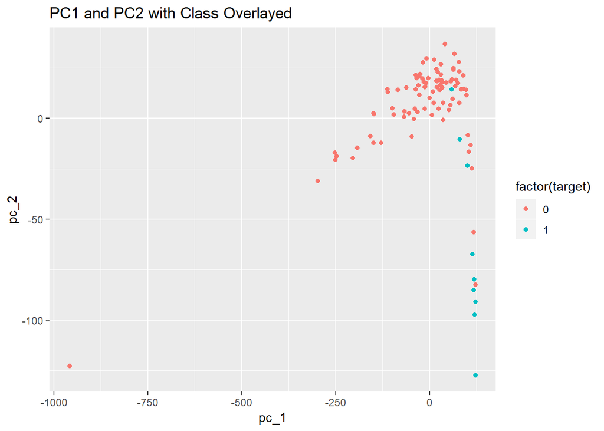

```r
pos = PCA[target == 1]
neg = PCA[target == 0]

# lets sample 100 data points
num_samples = 100
pos = pos[sample(1:nrow(pos), .09*num_samples)]
neg = neg[sample(1:nrow(neg), .91*num_samples)]
reduced_PCA = rbindlist(list(pos, neg))

ggplot(reduced_PCA, aes(x = pc_1, y = pc_2)) +
    geom_point(aes(col = factor(target))) +
    ggtitle("PC1 and PC2 with Class Overlayed")
```

### Building training and test sets

The process is as follows

- split data into training and testing sets (with even target distribution)
- compute projection matrix for training set and transform training set
- transform testing set using computed projection matrix from previous step

```r
# training set proportion
prop = .7

pos = stars[target == 1]
neg = stars[target == 0]
pos_ind = sample.int(nrow(pos), round(prop*nrow(pos)))
neg_ind = sample.int(nrow(neg), round(prop*nrow(neg)))

train = rbind(pos[pos_ind], neg[neg_ind])
train[, target := as.factor(target)]

test = rbind(pos[-pos_ind], neg[-neg_ind])
test[, target := as.factor(target)]
```

We have our training and testing sets which we can use for the duration of the analysis.

### PCA vs full features using Random Forest

```r
# number of pricipal components that you'd like to compute
num_pcs = 2

train_x = train[, !"target"]
train_y = train[, "target"]

# compute covariance
train_cov = cov(train_x)

# compute eigen decomposition on covariance matrix
eigen_train = eigen(train_cov)

scaled_train = scale(train_x, scale = FALSE)
train_pca = scaled_train %*% eigen_train$vectors[, 1:num_pcs]

train_pca = cbind(train_pca, train_y)
setnames(train_pca, names(train_pca)[1:num_pcs],
         paste("pc", 1:num_pcs, sep = "_"))

knitr::kable(head(train_pca), digits = 2,
             caption = "Projected Training Set")
```

Projected Training Set

| pc_1 | pc_2 | target |
| --- | --- | --- |
| 118.19 | -82.41 | 1 |
| 92.22 | -9.89 | 1 |
| 105.83 | -56.04 | 1 |
| 102.32 | -37.67 | 1 |
| 104.52 | -36.91 | 1 |
| 1.42 | -12.44 | 1 |

Above we have our transformed training set. Next we transform our testing set.

```r
test_x = test[, !"target"]
test_y = test[, .(target)]

transformed_test = scale(test_x, center = attr(scaled_train, "scaled:center"),
                       scale = FALSE) %*% eigen_train$vectors[, 1:num_pcs]

test_pca = cbind(transformed_test, test_y)
test_pca[, target := as.factor(target)]

setnames(test_pca, names(test_pca)[1:num_pcs],
         paste("pc", 1:num_pcs, sep = "_"))

knitr::kable(head(test_pca), digits = 2,
             caption = "Projected Test Set")
```

Projected Test Set

| pc_1 | pc_2 | target |
| --- | --- | --- |
| 117.22 | -91.31 | 1 |
| 75.94 | 5.47 | 1 |
| 115.48 | -81.55 | 1 |
| 131.59 | -179.05 | 1 |
| 101.12 | -1.95 | 1 |
| 129.35 | -157.60 | 1 |

Great! Now we have our training and test sets projected onto a new feature space. We’ve used the first two principal components here.

Now we can train our random forest!

```r
require(randomForest, quietly = TRUE)
```

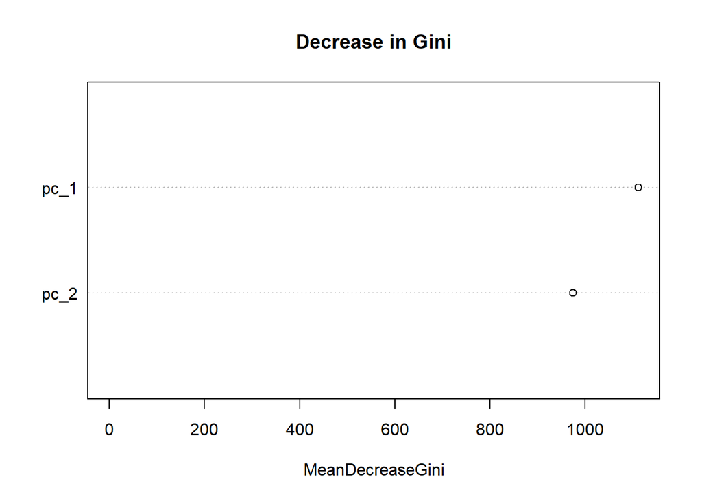

```r
RF_pca_no_samp = randomForest(x = train_pca[, !"target"],
                              y = train_pca[, target],
                              ntree = 1000, importance = TRUE)

varImpPlot(RF_pca_no_samp, type = 2,
           main = "Decrease in Gini")
```

Above we have a simple plot showing that, to no surprise, pc_1 was the more important feature between pc_1 and pc_2.

We can now test our random forest trained on transformed data.

```r
require(ROCR, quietly = TRUE)
preds_pca = predict(RF_pca_no_samp, newdata = test_pca[, !"target"],
                    type = "prob")[, 2]

# get performance of model
pred_obj = prediction(preds_pca, test_pca[, target])
c(AUC = performance(pred_obj, measure = "auc")@y.values[[1]])
```

```
##       AUC
## 0.9358821
```

```r
# as.numeric(as.character(test_pca[, target]))
```

An AUC of .94 is really good! We don’t know how good that is until we compare it to a data set using all of the features. **For comparison, we will use the exact same training and testing observations**.

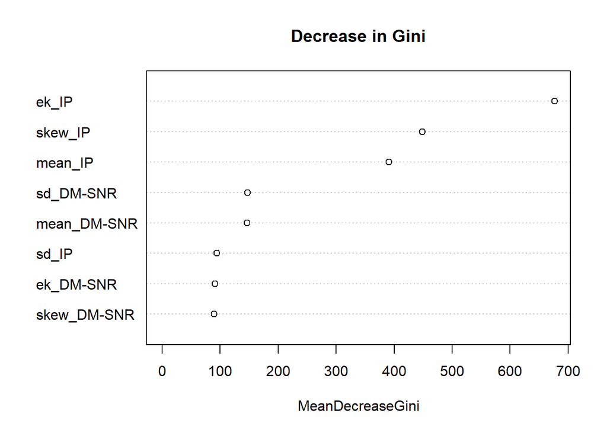

```r
RF_no_samp = randomForest(x = train[, !"target"],
                          y = train[, target],
                          ntree = 1000, importance = TRUE)

varImpPlot(RF_no_samp, type = 2,
           main = "Decrease in Gini")
```

Here we can see that the most important feature is the excess kurtosis of the integrated profile.

```r
preds = predict(RF_no_samp, newdata = test[, !"target"],
                type = "prob")[, 2]

# get performance of model
pred_obj = prediction(preds, test[, target])
c(AUC = performance(pred_obj, measure = "auc")@y.values[[1]])
```

```
##       AUC
## 0.9736818
```

An AUC of .97 is exceptional. That being said, using only 2 features instead of 8, we were able to get an AUC within .03 (.97-.94) of the model built on the entire data set!